# Computacion estadistica - Clase 6

# Tabla de Contenido

- Descarga de datos y carga de `dplyr`
- Agrupar y resumir con `group_by` + `summarise`
- Filtrar
- Joins
- Gráficos
  - Gráfico de barras
  - Histogramas
  - Boxplot (“Gráfico de caja”)

# Carga de datos `marketing.csv` y carga de `dplyr`

```r
library(readr)
marketing <- read_csv("BD/marketing.csv")
marketing
```

| ...1 | ID | Year_Birth | Education | Marital_Status | Income | Kidhome | Teenhome | Dt_Customer | Recency | MntWines | MntFruits | MntMeatProducts | MntFishProducts | MntSweetProducts | MntGoldProds | NumDealsPurchases | NumWebPurchases | NumCatalogPurchases | NumStorePurchases | NumWebVisitsMonth | AcceptedCmp3 | AcceptedCmp4 | AcceptedCmp5 | AcceptedCmp1 | AcceptedCmp2 | Response | Complain | Country |
| --- | --- | --- | --- | --- | --- | --- | --- | --- | --- | --- | --- | --- | --- | --- | --- | --- | --- | --- | --- | --- | --- | --- | --- | --- | --- | --- | --- | --- |
| 1 | 1826 | 1970 | Graduation | Divorced | 84835 | 0 | 0 | 6/16/14 | 0 | 189 | 104 | 379 | 111 | 189 | 218 | 1 | 4 | 4 | 6 | 1 | 0 | 0 | 0 | 0 | 0 | 1 | 0 | SP |
| 2 | 1 | 1961 | Graduation | Single | 57091 | 0 | 0 | 6/15/14 | 0 | 464 | 5 | 64 | 7 | 0 | 37 | 1 | 7 | 3 | 7 | 5 | 0 | 0 | 0 | 0 | 1 | 1 | 0 | CA |
| 3 | 10476 | 1958 | Graduation | Married | 67267 | 0 | 1 | 5/13/14 | 0 | 134 | 11 | 59 | 15 | 2 | 30 | 1 | 3 | 2 | 5 | 2 | 0 | 0 | 0 | 0 | 0 | 0 | 0 | US |
| 4 | 1386 | 1967 | Graduation | Together | 32474 | 1 | 1 | 5/11/2014 | 0 | 10 | 0 | 1 | 0 | 0 | 0 | 1 | 1 | 0 | 2 | 7 | 0 | 0 | 0 | 0 | 0 | 0 | 0 | AUS |
| 5 | 5371 | 1989 | Graduation | Single | 21474 | 1 | 0 | 4/08/2014 | 0 | 6 | 16 | 24 | 11 | 0 | 34 | 2 | 3 | 1 | 2 | 7 | 1 | 0 | 0 | 0 | 0 | 1 | 0 | SP |
| 6 | 7348 | 1958 | PhD | Single | 71691 | 0 | 0 | 3/17/14 | 0 | 336 | 130 | 411 | 240 | 32 | 43 | 1 | 4 | 7 | 5 | 2 | 0 | 0 | 0 | 0 | 0 | 1 | 0 | SP |
| 7 | 4073 | 1954 | 2n Cycle | Married | 63564 | 0 | 0 | 1/29/14 | 0 | 769 | 80 | 252 | 15 | 34 | 65 | 1 | 10 | 10 | 7 | 6 | 1 | 0 | 0 | 0 | 0 | 1 | 0 | GER |
| 8 | 1991 | 1967 | Graduation | Together | 44931 | 0 | 1 | 1/18/14 | 0 | 78 | 0 | 11 | 0 | 0 | 7 | 1 | 2 | 1 | 3 | 5 | 0 | 0 | 0 | 0 | 0 | 0 | 0 | SP |
| 9 | 4047 | 1954 | PhD | Married | 65324 | 0 | 1 | 1/11/2014 | 0 | 384 | 0 | 102 | 21 | 32 | 5 | 3 | 6 | 2 | 9 | 4 | 0 | 0 | 0 | 0 | 0 | 0 | 0 | US |
| 10 | 9477 | 1954 | PhD | Married | 65324 | 0 | 1 | 1/11/2014 | 0 | 384 | 0 | 102 | 21 | 32 | 5 | 3 | 6 | 2 | 9 | 4 | 0 | 0 | 0 | 0 | 0 | 0 | 0 | IND |

[output cut: 990 more lines]

```r
library(dplyr)
```

🔝 Volver a tabla de contenido

# Agrupar y resumir con `group_by` + `summarise`

> Si analizas cada uno, va de lo grande a lo chico, de lo general a lo específico.

Ingreso promedio por nivel educativo:

```r
marketing %>%
  group_by(Education) %>%
  summarise(Ingreso = mean(Income, na.rm = TRUE)) # remove NA = TRUE
```

| Education | Ingreso |
| --- | --- |
| 2n Cycle | 47633.19 |
| Basic | 20306.26 |
| Graduation | 52720.37 |
| Master | 52917.53 |
| PhD | 56145.31 |

Ingreso promedio por educación y estado civil:

```r
marketing %>%
  group_by(Education, Marital_Status) %>%
  summarise(Ingreso = mean(Income, na.rm = TRUE))
```

| Education | Marital_Status | Ingreso |
| --- | --- | --- |
| 2n Cycle | Divorced | 49395.13 |
| 2n Cycle | Married | 46201.10 |
| 2n Cycle | Single | 53673.94 |
| 2n Cycle | Together | 44736.41 |
| 2n Cycle | Widow | 51392.20 |
| Basic | Divorced | 9548.00 |
| Basic | Married | 21960.50 |
| Basic | Single | 18238.67 |
| Basic | Together | 21240.07 |
| Basic | Widow | 22123.00 |

[output cut: 21 more lines]

🔝 Volver a tabla de contenido

# Filtrar

Solo personas casadas:

```r
marketing %>% filter(Marital_Status == "Married")
```

| ...1 | ID | Year_Birth | Education | Marital_Status | Income | Kidhome | Teenhome | Dt_Customer | Recency | MntWines | MntFruits | MntMeatProducts | MntFishProducts | MntSweetProducts | MntGoldProds | NumDealsPurchases | NumWebPurchases | NumCatalogPurchases | NumStorePurchases | NumWebVisitsMonth | AcceptedCmp3 | AcceptedCmp4 | AcceptedCmp5 | AcceptedCmp1 | AcceptedCmp2 | Response | Complain | Country |
| --- | --- | --- | --- | --- | --- | --- | --- | --- | --- | --- | --- | --- | --- | --- | --- | --- | --- | --- | --- | --- | --- | --- | --- | --- | --- | --- | --- | --- |
| 3 | 10476 | 1958 | Graduation | Married | 67267 | 0 | 1 | 5/13/14 | 0 | 134 | 11 | 59 | 15 | 2 | 30 | 1 | 3 | 2 | 5 | 2 | 0 | 0 | 0 | 0 | 0 | 0 | 0 | US |
| 7 | 4073 | 1954 | 2n Cycle | Married | 63564 | 0 | 0 | 1/29/14 | 0 | 769 | 80 | 252 | 15 | 34 | 65 | 1 | 10 | 10 | 7 | 6 | 1 | 0 | 0 | 0 | 0 | 1 | 0 | GER |
| 9 | 4047 | 1954 | PhD | Married | 65324 | 0 | 1 | 1/11/2014 | 0 | 384 | 0 | 102 | 21 | 32 | 5 | 3 | 6 | 2 | 9 | 4 | 0 | 0 | 0 | 0 | 0 | 0 | 0 | US |
| 10 | 9477 | 1954 | PhD | Married | 65324 | 0 | 1 | 1/11/2014 | 0 | 384 | 0 | 102 | 21 | 32 | 5 | 3 | 6 | 2 | 9 | 4 | 0 | 0 | 0 | 0 | 0 | 0 | 0 | IND |
| 11 | 2079 | 1947 | 2n Cycle | Married | 81044 | 0 | 0 | 12/27/13 | 0 | 450 | 26 | 535 | 73 | 98 | 26 | 1 | 5 | 6 | 10 | 1 | 0 | 0 | 0 | 0 | 0 | 0 | 0 | US |
| 14 | 2964 | 1981 | Graduation | Married | 26872 | 0 | 0 | 10/16/13 | 0 | 3 | 10 | 8 | 3 | 16 | 32 | 1 | 1 | 1 | 2 | 6 | 0 | 0 | 0 | 0 | 0 | 0 | 0 | CA |
| 15 | 10311 | 1969 | Graduation | Married | 4428 | 0 | 1 | 10/05/2013 | 0 | 16 | 4 | 12 | 2 | 4 | 321 | 0 | 25 | 0 | 0 | 1 | 0 | 0 | 0 | 0 | 0 | 0 | 0 | SP |
| 16 | 837 | 1977 | Graduation | Married | 54809 | 1 | 1 | 9/11/2013 | 0 | 63 | 6 | 57 | 13 | 13 | 22 | 4 | 2 | 1 | 5 | 4 | 0 | 0 | 0 | 0 | 0 | 0 | 0 | SP |
| 17 | 10521 | 1977 | Graduation | Married | 54809 | 1 | 1 | 9/11/2013 | 0 | 63 | 6 | 57 | 13 | 13 | 22 | 4 | 2 | 1 | 5 | 4 | 0 | 0 | 0 | 0 | 0 | 1 | 0 | SP |
| 23 | 10470 | 1979 | Master | Married | 40662 | 1 | 0 | 3/15/13 | 0 | 40 | 2 | 23 | 0 | 4 | 23 | 2 | 2 | 1 | 3 | 4 | 0 | 0 | 0 | 0 | 0 | 0 | 0 | GER |

[output cut: 847 more lines]

Casados o divorciados (nivel pollito 😄):

```r
marketing %>% filter(Marital_Status %in% c("Married", "Divorced"))
```

| ...1 | ID | Year_Birth | Education | Marital_Status | Income | Kidhome | Teenhome | Dt_Customer | Recency | MntWines | MntFruits | MntMeatProducts | MntFishProducts | MntSweetProducts | MntGoldProds | NumDealsPurchases | NumWebPurchases | NumCatalogPurchases | NumStorePurchases | NumWebVisitsMonth | AcceptedCmp3 | AcceptedCmp4 | AcceptedCmp5 | AcceptedCmp1 | AcceptedCmp2 | Response | Complain | Country |
| --- | --- | --- | --- | --- | --- | --- | --- | --- | --- | --- | --- | --- | --- | --- | --- | --- | --- | --- | --- | --- | --- | --- | --- | --- | --- | --- | --- | --- |
| 1 | 1826 | 1970 | Graduation | Divorced | 84835 | 0 | 0 | 6/16/14 | 0 | 189 | 104 | 379 | 111 | 189 | 218 | 1 | 4 | 4 | 6 | 1 | 0 | 0 | 0 | 0 | 0 | 1 | 0 | SP |
| 3 | 10476 | 1958 | Graduation | Married | 67267 | 0 | 1 | 5/13/14 | 0 | 134 | 11 | 59 | 15 | 2 | 30 | 1 | 3 | 2 | 5 | 2 | 0 | 0 | 0 | 0 | 0 | 0 | 0 | US |
| 7 | 4073 | 1954 | 2n Cycle | Married | 63564 | 0 | 0 | 1/29/14 | 0 | 769 | 80 | 252 | 15 | 34 | 65 | 1 | 10 | 10 | 7 | 6 | 1 | 0 | 0 | 0 | 0 | 1 | 0 | GER |
| 9 | 4047 | 1954 | PhD | Married | 65324 | 0 | 1 | 1/11/2014 | 0 | 384 | 0 | 102 | 21 | 32 | 5 | 3 | 6 | 2 | 9 | 4 | 0 | 0 | 0 | 0 | 0 | 0 | 0 | US |
| 10 | 9477 | 1954 | PhD | Married | 65324 | 0 | 1 | 1/11/2014 | 0 | 384 | 0 | 102 | 21 | 32 | 5 | 3 | 6 | 2 | 9 | 4 | 0 | 0 | 0 | 0 | 0 | 0 | 0 | IND |
| 11 | 2079 | 1947 | 2n Cycle | Married | 81044 | 0 | 0 | 12/27/13 | 0 | 450 | 26 | 535 | 73 | 98 | 26 | 1 | 5 | 6 | 10 | 1 | 0 | 0 | 0 | 0 | 0 | 0 | 0 | US |
| 14 | 2964 | 1981 | Graduation | Married | 26872 | 0 | 0 | 10/16/13 | 0 | 3 | 10 | 8 | 3 | 16 | 32 | 1 | 1 | 1 | 2 | 6 | 0 | 0 | 0 | 0 | 0 | 0 | 0 | CA |
| 15 | 10311 | 1969 | Graduation | Married | 4428 | 0 | 1 | 10/05/2013 | 0 | 16 | 4 | 12 | 2 | 4 | 321 | 0 | 25 | 0 | 0 | 1 | 0 | 0 | 0 | 0 | 0 | 0 | 0 | SP |
| 16 | 837 | 1977 | Graduation | Married | 54809 | 1 | 1 | 9/11/2013 | 0 | 63 | 6 | 57 | 13 | 13 | 22 | 4 | 2 | 1 | 5 | 4 | 0 | 0 | 0 | 0 | 0 | 0 | 0 | SP |
| 17 | 10521 | 1977 | Graduation | Married | 54809 | 1 | 1 | 9/11/2013 | 0 | 63 | 6 | 57 | 13 | 13 | 22 | 4 | 2 | 1 | 5 | 4 | 0 | 0 | 0 | 0 | 0 | 1 | 0 | SP |

[output cut: 990 more lines]

*Evitar uso de notación científica*

```r
options(scipen = 99)
```

🔝 Volver a tabla de contenido

# joins

| Función | Qué hace |
| --- | --- |
| `filter()` | Filtra filas (por ejemplo, solo 2020) |
| `left_join()` | Une dos tablas, conservando todo lo de la primera |
| `right_join()` | Conserva todo lo de la segunda |
| `full_join()` | Conserva todo de ambas |
| `select(-col)` | Elimina una columna antes de unir |

> Para esta parte, se necesita cargar al entorno R el archivo `datos_economicos.RData`, que trae las siquientes tablas:

```r
df_balanza
```

| pais | año | balanza_comercial |
| --- | --- | --- |
| España | 2019 | -5000000000 |
| Alemania | 2019 | 20000000000 |
| Francia | 2019 | -2000000000 |
| Italia | 2019 | 3000000000 |

```r
df_desempleo
```

| pais | año | desempleo |
| --- | --- | --- |
| España | 2019 | 14.1 |
| España | 2020 | 15.3 |
| Alemania | 2019 | 3.2 |
| Alemania | 2020 | 4.0 |
| Francia | 2018 | 9.0 |
| Francia | 2019 | 8.5 |

```r
df_inflacion
```

| pais | año | inflacion |
| --- | --- | --- |
| España | 2018 | 1.7 |
| España | 2019 | 2.0 |
| España | 2020 | 0.5 |
| Alemania | 2018 | 1.8 |
| Alemania | 2019 | 1.4 |
| Alemania | 2020 | 0.3 |
| Italia | 2019 | 1.2 |
| Italia | 2020 | 0.8 |

```r
df_pib
```

| pais | año | PIB |
| --- | --- | --- |
| España | 2018 | 1200000000000 |
| España | 2019 | 1300000000000 |
| España | 2020 | 1100000000000 |
| Alemania | 2018 | 3400000000000 |
| Alemania | 2019 | 3500000000000 |
| Alemania | 2020 | 3200000000000 |
| Francia | 2018 | 2100000000000 |
| Francia | 2019 | 2200000000000 |

**Filtremos** para obtener los datos del **pib**, **desempleo** e **inflacion** del año **2020:**

```r
pib20 = df_pib %>% filter(año == 2020)        # PIB solo 2020
des20 = df_desempleo %>% filter(año == 2020)  # Desempleo 2020
inf20 = df_inflacion %>% filter(año == 2020)  # Inflación 2020
```

```r
pib20
```

| pais | año | PIB |
| --- | --- | --- |
| España | 2020 | 1100000000000 |
| Alemania | 2020 | 3200000000000 |

```r
des20
```

| pais | año | desempleo |
| --- | --- | --- |
| España | 2020 | 15.3 |
| Alemania | 2020 | 4.0 |

```r
inf20
```

| pais | año | inflacion |
| --- | --- | --- |
| España | 2020 | 0.5 |
| Alemania | 2020 | 0.3 |
| Italia | 2020 | 0.8 |

Ahora hagamos consultas sobre estos datos usando **joins**.

- 🧠 “Une la información de **PIB 2020** con la de **inflación** por **país y año**, manteniendo todos los datos del PIB del 2020 y agregando la inflación *solo si existe una coincidencia*.”:

```r
tabla_left <- left_join(pib20, inf20, by = c('pais', 'año'))
tabla_left
```

| pais | año | PIB | inflacion |
| --- | --- | --- | --- |
| España | 2020 | 1100000000000 | 0.5 |
| Alemania | 2020 | 3200000000000 | 0.3 |

> En `dplyr`, el argumento `by` funciona como si estuvieras indicando las claves (o “keys”) por las que se deben unir las tablas, igual que harías con una clave primaria y una clave foránea en bases de datos.
- 🧠 “Une la información de **inflación** a los datos del **PIB 2020** **solo por país**, **sin considerar el año**,manteniendo todos los datos del PIB del 2020 y agregando la inflación *solo si existe una coincidencia*.” Esto puede provocar uniones incorrectas si hay varias filas por país en alguna tabla.:

```r
tabla_left1 = left_join(pib20, inf20 %>% select(-año), by = "pais")
# inf20 %>% select(-año): elimina la columna año antes del join.
tabla_left1
```

| pais | año | PIB | inflacion |
| --- | --- | --- | --- |
| España | 2020 | 1100000000000 | 0.5 |
| Alemania | 2020 | 3200000000000 | 0.3 |

- 🧠 “Une la información del **PIB del 2020** a los datos de **inflación del 2020**, conservando todos los países con datos de **inflación** y agregando el **PIB** *solo si hay coincidencia por país y año*.”:

```r
tabla_right = right_join(pib20, inf20, by = c("pais", "año"))
tabla_right
```

| pais | año | PIB | inflacion |
| --- | --- | --- | --- |
| España | 2020 | 1100000000000 | 0.5 |
| Alemania | 2020 | 3200000000000 | 0.3 |
| Italia | 2020 | NA | 0.8 |

- 🧠 “Une la información de **inflación** a los datos de **desempleo** por **país y año**, manteniendo **todos los datos de desempleo** aunque no haya registro de inflación para ese país y año.( agregando la inflación *solo si existe una coincidencia*)”:

```r
# left_join(df_desempleo, df_inflacion, by = c("pais", "año")) %>% View()

left_join(df_desempleo, df_inflacion, by = c("pais", "año"))
```

| pais | año | desempleo | inflacion |
| --- | --- | --- | --- |
| España | 2019 | 14.1 | 2.0 |
| España | 2020 | 15.3 | 0.5 |
| Alemania | 2019 | 3.2 | 1.4 |
| Alemania | 2020 | 4.0 | 0.3 |
| Francia | 2018 | 9.0 | NA |
| Francia | 2019 | 8.5 | NA |

- 🧠 “Dame todos los países que estén en cualquiera de las dos tablas, aunque no coincidan. // Combina todos los datos de desempleo e inflación por país y año, incluso si no hay coincidencias entre ambas tablas.”:

```r
# full_join(df_desempleo, df_inflacion, by = c("pais", "año")) %>% View()
full_join(df_desempleo, df_inflacion, by = c("pais", "año"))
```

| pais | año | desempleo | inflacion |
| --- | --- | --- | --- |
| España | 2019 | 14.1 | 2.0 |
| España | 2020 | 15.3 | 0.5 |
| Alemania | 2019 | 3.2 | 1.4 |
| Alemania | 2020 | 4.0 | 0.3 |
| Francia | 2018 | 9.0 | NA |
| Francia | 2019 | 8.5 | NA |
| España | 2018 | NA | 1.7 |
| Alemania | 2018 | NA | 1.8 |
| Italia | 2019 | NA | 1.2 |
| Italia | 2020 | NA | 0.8 |

🔝 Volver a tabla de contenido

# Gráficos

```r
table(marketing$Education)
```

```
  2n Cycle      Basic Graduation     Master        PhD
       200         54       1116        365        481
```

```r
# Cuenta cuántas veces aparece cada nivel educativo
# Devuelve una tabla de frecuencias
```

## Gráfico de barras

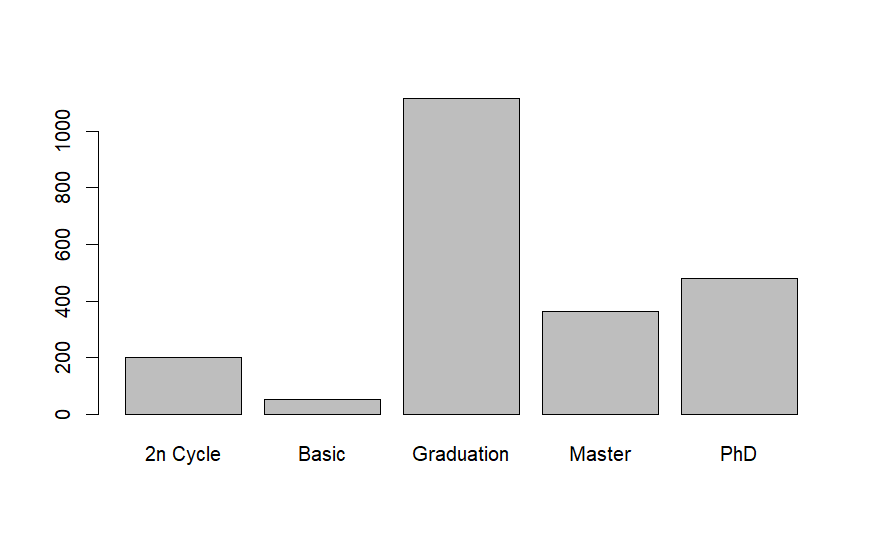

```r
barplot(table(marketing$Education))
```

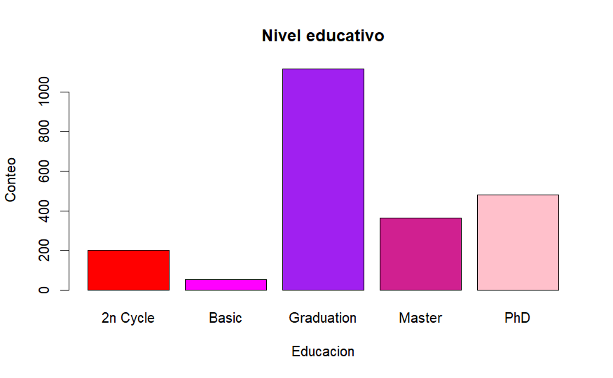

```r
# Muestra un gráfico de barras básico con los conteos anteriores

x = table(marketing$Education)
barplot(x, main = "Nivel educativo", xlab = "Educacion", ylab = "Conteo",
        col = c("red", "magenta", "purple", "violetred", "pink"))
```

🔝 Volver a tabla de contenido

## Histogramas

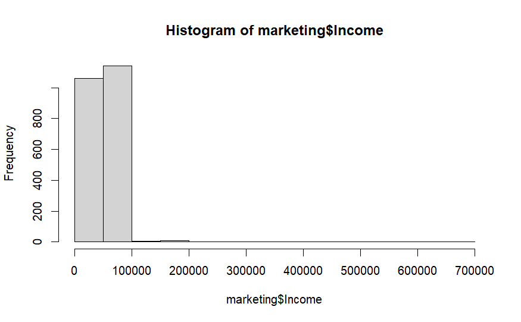

```r
hist(marketing$Income)
```

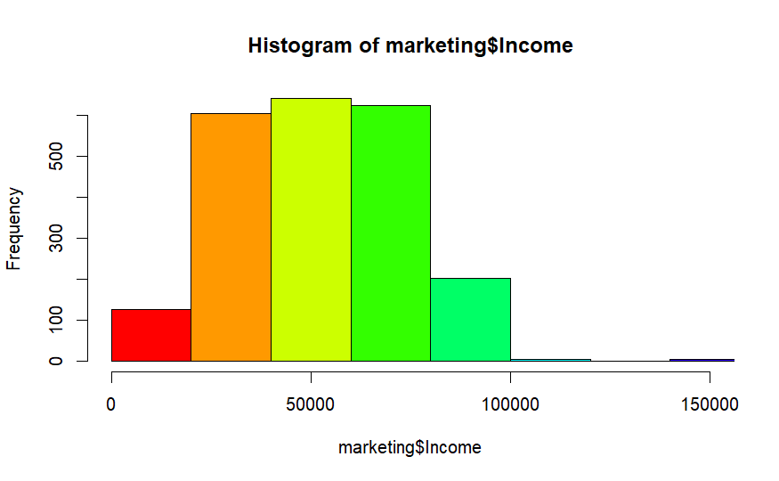

```r
hist(marketing$Income, xlim = c(0, 150000), breaks = 30, col = rainbow(10))
```

- `xlim=c(0, 150000)`: recorta eje X
- `breaks=30`: más detalle en los bloques
- `col=rainbow(10)`: paleta de 10 colores

```r
histo1 = hist(marketing$Income, xlim = c(0, 150000), breaks = 50, col = rainbow(10))
```

[output not shown]

🔝 Volver a tabla de contenido

## Boxplot (“Gráfico de caja”)

Filtra para eliminar ingresos extremos (outliers):

```r
marketing2 = marketing %>% filter(Income <= 200000)
```

Creamos el grafico de cajas

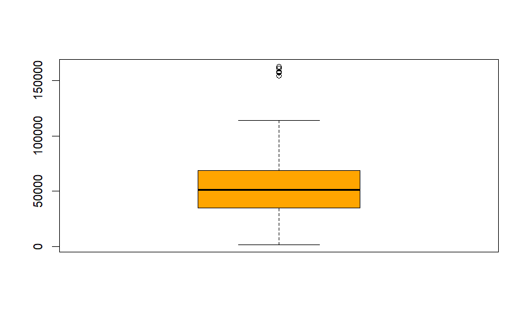

```r
cajita = boxplot(marketing2$Income, col = "orange")
```

### Mostramos cuartiles

```r
cajita$stats
```

```
       [,1]
[1,]   1730
[2,]  35284
[3,]  51373
[4,]  68487
[5,] 113734
```

### Muestra los valores atípicos detectados

```r
cajita$out
```

```
[1] 157146 160803 162397 157733 153924 156924 157243
```

🔝 Volver a tabla de contenido